# Statistics summary: psychophysics from VEP study

## Participant details

Total sample size: 21

- Control n = 9
- Amblyopia n = 10
- Binocular disorder (no amblyopia) n = 2

## Calibration parameters

- Calibration range (p.clean_range): 0.3
- Mean good trials per person (p.n_good): 28.1 (range: 27 to 30)

### Delay (in sec):

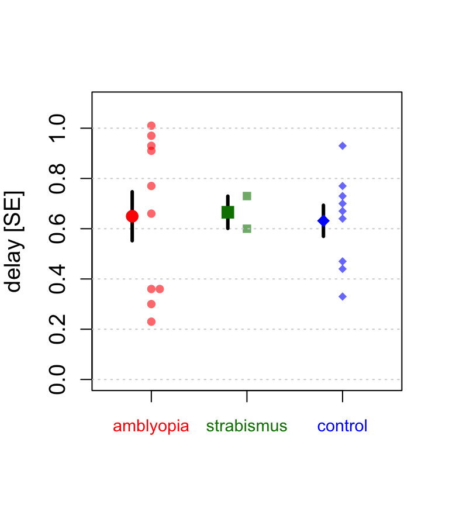

**Mean (SD) values:**

- Control: 0.63 (0.19)
- Amblyopia: 0.65 (0.31)
  - Amblyopia vs. controls: t(15) = 0.16, p = 0.88; Glass’s ∆ = 0.1
- Strabismus with equal acuity: 0.67 (0.09)

### Intercept (a):

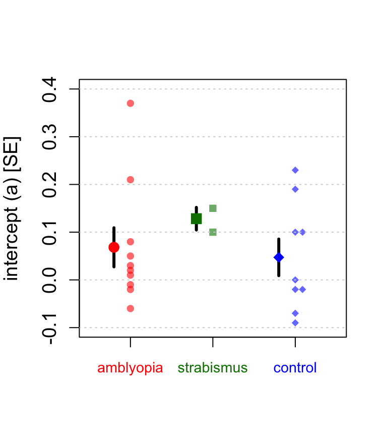

**Mean (SD) values:**

- Control: 0.05 (0.11)
- Amblyopia: 0.07 (0.13)
  - Amblyopia vs. controls: t(17) = 0.38, p = 0.71; Glass’s ∆ = 0.18
- Strabismus with equal acuity: 0.13 (0.03)

### Slope (b):

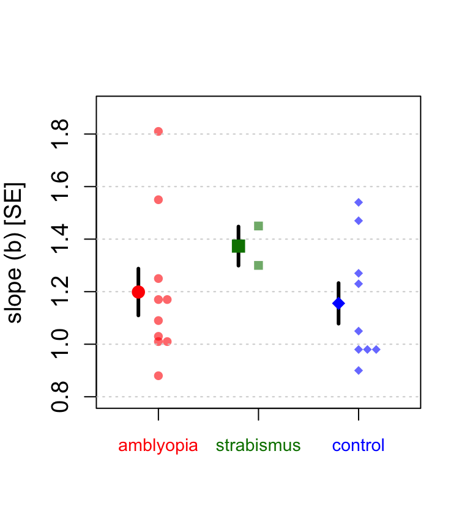

**Mean (SD) values:**

- Control: 1.16 (0.23)
- Amblyopia: 1.2 (0.28)
  - Amblyopia vs. controls: t(16.9) = 0.37, p = 0.72; Glass’s ∆ = 0.19
- Strabismus with equal acuity: 1.37 (0.11)

### Calibration error (mean across trials):

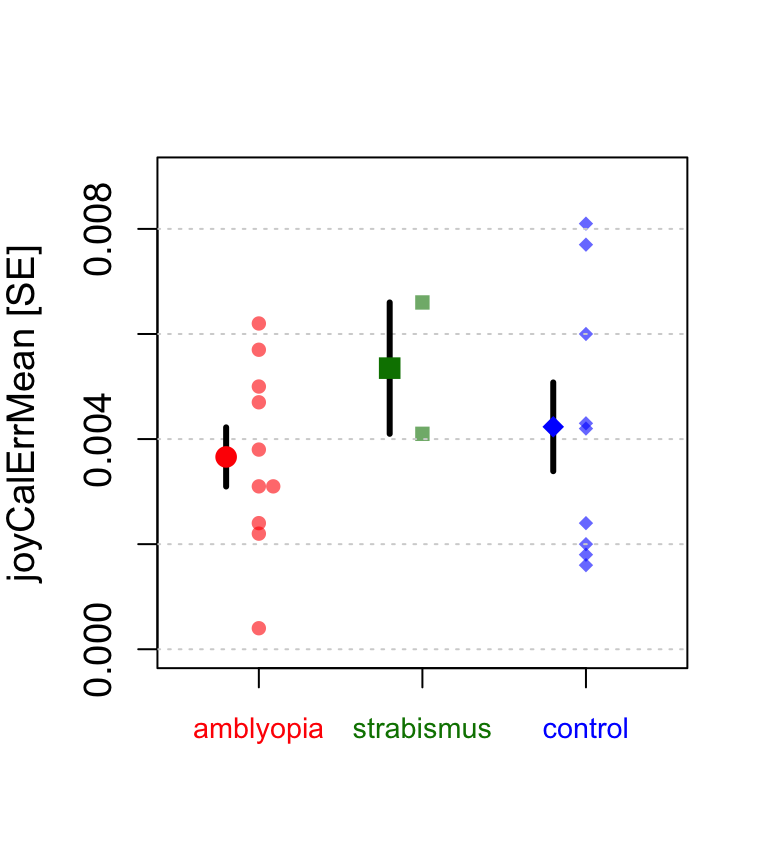

**Mean (SD) values:**

- Control: 0.0042 (0.0025)
- Amblyopia: 0.0037 (0.0018)
  - Amblyopia vs. controls: t(14.2) = 0.57, p = 0.58; Glass’s ∆ = 0.23
- Strabismus with equal acuity: 0.01 (0.0018)

### Calibration error (individual trials):

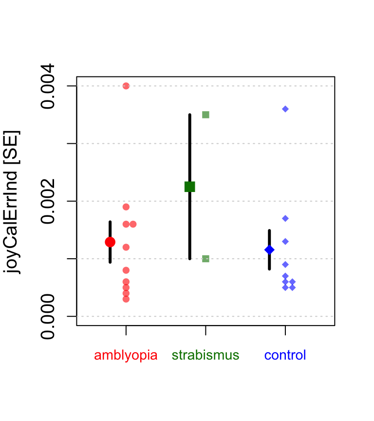

**Mean (SD) values:**

- Control: 0.0011 (0.001)
- Amblyopia: 0.0013 (0.0011)
  - Amblyopia vs. controls: t(17) = 0.31, p = 0.76; Glass’s ∆ = 0.15
- Strabismus with equal acuity: 0 (0.0018)

## Model parameters

### Attenuation (k_AE)

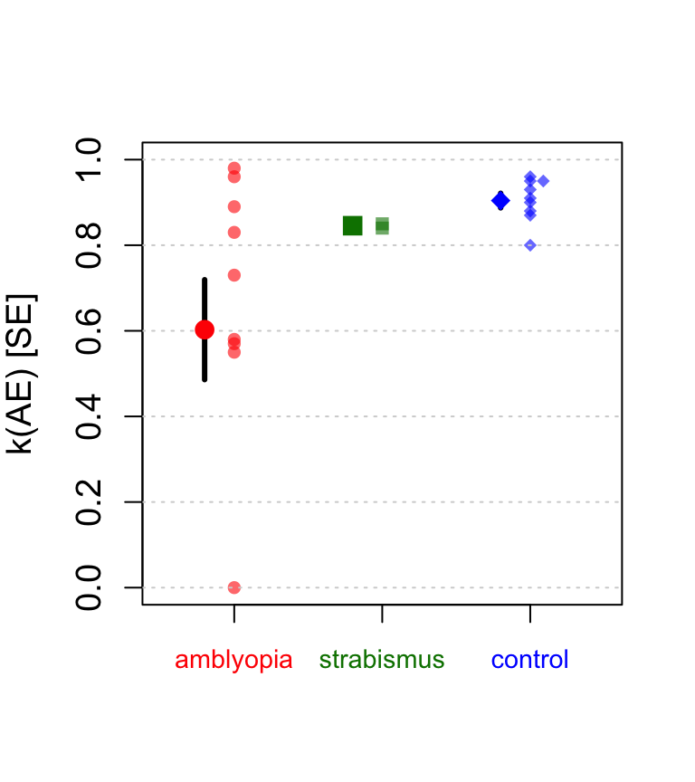

**Mean (SD) values:**

- Control: 0.9 (0.05)
- Amblyopia: 0.6 (0.37)
  - Amblyopia vs. controls: t(9.4) = 2.56, p = 0.03; Glass’s ∆ = 5.9
- Strabismus with equal acuity: 0.85 (0.01)

### U values

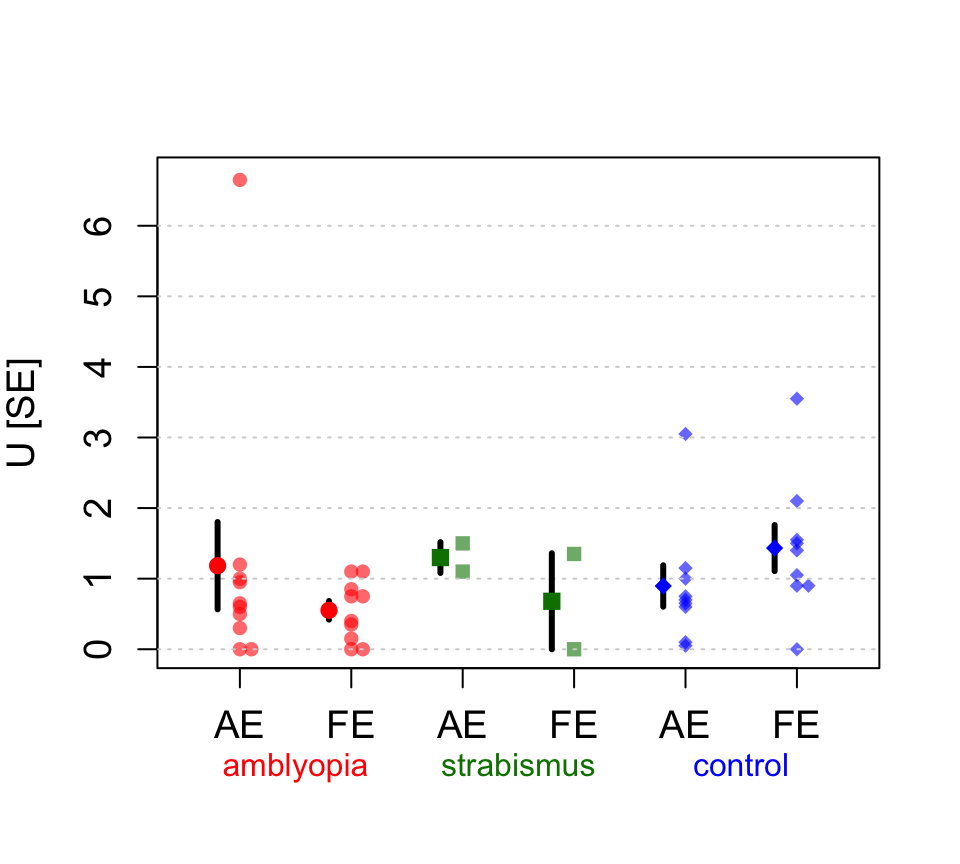

**Mean (SD) values, u_AE:**

- Control: 0.9 (0.88)
- Amblyopia: 1.18 (1.95)
- Strabismus with equal acuity: 1.3 (0.31)

**Mean (SD) values, u_FE:**

- Control: 1.43 (0.98)
- Amblyopia: 0.55 (0.42)
- Strabismus with equal acuity: 0.68 (0.96)

**$\mu$ ANOVA test:**

- No main effect of group, F(1,17) = 0.82, p = 0.38, ges = 0.016
- no main effect of eye, F(1,17) = 0.01, p = 0.92, ges = 0.00043
- no group by eye interaction, F(1,17) = 1.7, p = 0.21, ges = 0.061
- Simple main effects: no difference in uAE, F(1,17) = 0.16, p = 0.69, ges = 0.01
- Simple main effects: difference in uFE, F(1,17) = 6.8, p = 0.018, ges = 0.29

### Sigma

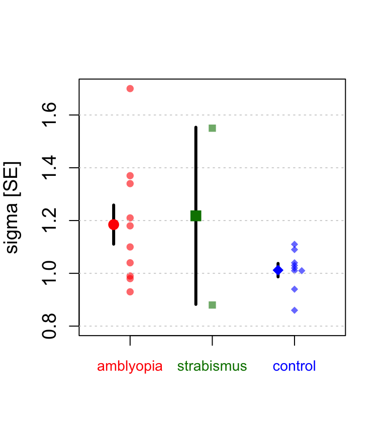

**Mean (SD) values:**

- Control: 1.01 (0.08)
- Amblyopia: 1.18 (0.23)
  - Amblyopia vs. controls: t(11.1) = 2.21, p = 0.05; Glass’s ∆ = 2.27
- Strabismus with equal acuity: 1.22 (0.47)

### Fit error

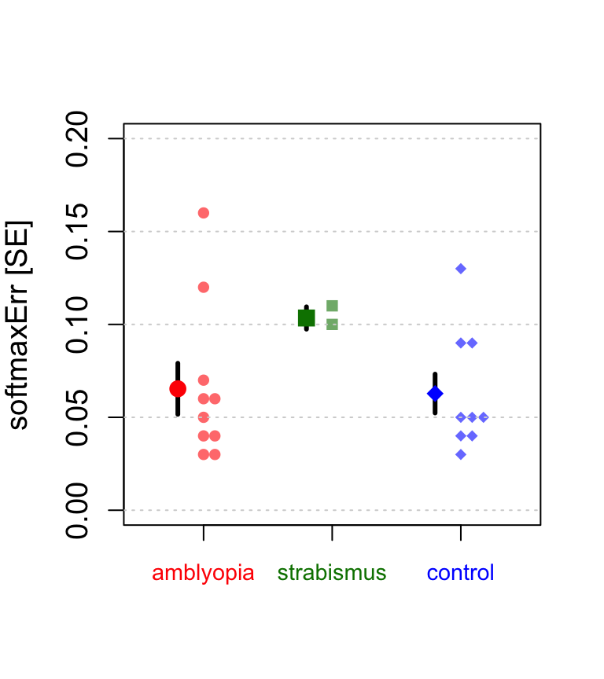

**Mean (SD) values:**

- Control: 0.063 (0.031)
- Amblyopia: 0.065 (0.043)
  - Amblyopia vs. controls: t(16.3) = 0.15, p = 0.88; Glass’s ∆ = 0.08
- Strabismus with equal acuity: 0.1 (0.008)